CMSC320 Sabrina Field

# Tutorial of the Data Science Pipeline

### The Data Science Pipeline

In this tutorial, we are going to learn the steps of the data pipeline by asking the question - Which groups of people are most affected by shootings? The steps of this tutorial's data pipeline will include:

**Data collection/curation + parsing (if necessary**

**Data management and representation**

**Exploratory data analysis**

**Hypothesis testing and machine learning**

**The communication of insights attained**

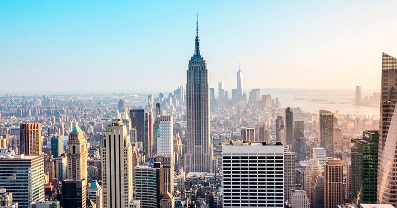

```python
# This is just for style purposes, it can be ignored :-)
from IPython import display
display.Image("https://www1.nyc.gov/assets/sustainability/images/content/pages/buildings.jpg")
```

## Which groups of people are most affected by shootings?

#### Introduction

Firearm related violence and has become a prevalent topic in conversations in the United States especially surrounding gun control. However, there is an extremely important aspect that is less acknowledged: who are the groups of people that tend to be victims? For example, the prominence of school shooting discussion makes any student feel more uneasy than someone who is not. Are there certain groups of people that are more affected than others? This would provide valuable insight into understanding where solution efforts need to be focused. As government and various nonprofit organizations work to deal with these issues, it is crucial to learn where resources need to be concentrated in bettering education, mental health support, and efforts of protection. If there is any identifiable trend, among location/age/etc., it might also have the capablility to demonstrate what is actually happening and show where resources must be focused.

Data is found at https://data.cityofnewyork.us/Public-Safety/NYPD-Shooting-Incident-Data-Historic-/833y-fsy8 found through https://catalog.data.gov/

#### Data collection/curation + parsing (if necessary)

The first step is data collection/curation + parsing. This step is primarily focused on locating where the data is and putting it in an accessible location. A website? A file? and then subsequently finding the steps to properly get the data in order to achieve this. This can be done in numerous ways such as using a website/database/source's API, using a module to access elements, or using a downloadable file.

Let's explore data collection/curation.

```python
# In the code we will be using import frequently for modules.
# Modules are python source code file sets that we can import.
# Modules are useful for using tools that others have built.

import pandas as pd # Pandas is a data analysis tool
```

Thankfully this site provided a very convenient downloadable CSV file which Pandas can read in as a Dataframe. Dataframes will be covered more in detail in the data management section. For now lets just focus on obtaining the data.

```python
data = pd.read_csv("NYPD_Shooting_Incident_Data__Historic_.csv")
data.head()
data
```

|  | INCIDENT_KEY | OCCUR_DATE | OCCUR_TIME | BORO | PRECINCT | JURISDICTION_CODE | LOCATION_DESC | STATISTICAL_MURDER_FLAG | PERP_AGE_GROUP | PERP_SEX | PERP_RACE | VIC_AGE_GROUP | VIC_SEX | VIC_RACE | X_COORD_CD | Y_COORD_CD | Latitude | Longitude | Lon_Lat |
| --- | --- | --- | --- | --- | --- | --- | --- | --- | --- | --- | --- | --- | --- | --- | --- | --- | --- | --- | --- |
| 0 | 201575314 | 08/23/2019 | 22:10:00 | QUEENS | 103 | 0.0 | NaN | False | NaN | NaN | NaN | 25-44 | M | BLACK | 1037451 | 193561 | 40.697805 | -73.808141 | POINT (-73.80814071699996 40.697805308000056) |
| 1 | 205748546 | 11/27/2019 | 15:54:00 | BRONX | 40 | 0.0 | NaN | False | <18 | M | BLACK | 25-44 | F | BLACK | 1006789 | 237559 | 40.818700 | -73.918571 | POINT (-73.91857061799993 40.81869973000005) |
| 2 | 193118596 | 02/02/2019 | 19:40:00 | MANHATTAN | 23 | 0.0 | NaN | False | 18-24 | M | WHITE HISPANIC | 18-24 | M | BLACK HISPANIC | 999347 | 227795 | 40.791916 | -73.945480 | POINT (-73.94547965999999 40.791916091000076) |
| 3 | 204192600 | 10/24/2019 | 00:52:00 | STATEN ISLAND | 121 | 0.0 | PVT HOUSE | True | 25-44 | M | BLACK | 25-44 | F | BLACK | 938149 | 171781 | 40.638064 | -74.166108 | POINT (-74.16610830199996 40.63806398200006) |
| 4 | 201483468 | 08/22/2019 | 18:03:00 | BRONX | 46 | 0.0 | NaN | False | 25-44 | M | BLACK HISPANIC | 18-24 | M | BLACK | 1008224 | 250621 | 40.854547 | -73.913339 | POINT (-73.91333944399999 40.85454734900003) |
| ... | ... | ... | ... | ... | ... | ... | ... | ... | ... | ... | ... | ... | ... | ... | ... | ... | ... | ... | ... |
| 23563 | 216936948 | 08/21/2020 | 02:10:00 | BRONX | 48 | 0.0 | MULTI DWELL - APT BUILD | True | NaN | NaN | NaN | 45-64 | M | BLACK HISPANIC | 1007277 | 187698 | 40.681843 | -73.916978 | POINT (-73.91697825799997 40.681842679000056) |
| 23564 | 214926175 | 07/03/2020 | 23:49:00 | QUEENS | 102 | 0.0 | HOTEL/MOTEL | False | <18 | M | BLACK | <18 | M | BLACK | 1005993 | 241333 | 40.829060 | -73.921434 | POINT (-73.92143424399995 40.82906028200006) |
| 23565 | 220870730 | 11/21/2020 | 08:05:00 | BROOKLYN | 60 | 0.0 | NaN | True | NaN | NaN | NaN | 45-64 | M | WHITE | 1046405 | 187113 | 40.680049 | -73.775909 | POINT (-73.77590919399995 40.680048726000045) |
| 23566 | 208187330 | 01/18/2020 | 01:00:00 | BRONX | 42 | 2.0 | MULTI DWELL - PUBLIC HOUS | False | NaN | NaN | NaN | 45-64 | M | BLACK | 1011373 | 182202 | 40.666746 | -73.902232 | POINT (-73.90223237399994 40.66674580000005) |
| 23567 | 220848244 | 11/21/2020 | 15:35:00 | BROOKLYN | 79 | 2.0 | MULTI DWELL - PUBLIC HOUS | False | 25-44 | M | BLACK | 25-44 | M | BLACK | 999475 | 172871 | 40.641163 | -73.945142 | POINT (-73.94514161199999 40.64116269600004) |

23568 rows × 19 columns

But what would happen if there wasn't a conveniently accessible file to download? The interesting part of data collection is there are frequently several ways to obtain the data. The most important part is finding the most suitable way for a given dataset.

Let's pretend there is no convenient CSV and check out a different way to access this data just to see what another method might look like.

```python
import requests as rq # Requests is an HTTP library
```

```python
url = "https://data.cityofnewyork.us/resource/833y-fsy8.json" # url of dataset
response = rq.get(url) # getting the url response stream
response = response.text # converting response stream to text
df = pd.read_json(response) # reading the data
df.head() # Let's check out the data...
```

|  | incident_key | occur_date | occur_time | boro | precinct | jurisdiction_code | statistical_murder_flag | vic_age_group | vic_sex | vic_race | ... | geocoded_column | :@computed_region_efsh_h5xi | :@computed_region_f5dn_yrer | :@computed_region_yeji_bk3q | :@computed_region_92fq_4b7q | :@computed_region_sbqj_enih | perp_age_group | perp_sex | perp_race | location_desc |
| --- | --- | --- | --- | --- | --- | --- | --- | --- | --- | --- | --- | --- | --- | --- | --- | --- | --- | --- | --- | --- | --- |
| 0 | 201575314 | 2019-08-23T00:00:00.000 | 2021-07-21 22:10:00 | QUEENS | 103 | 0.0 | False | 25-44 | M | BLACK | ... | {'type': 'Point', 'coordinates': [-73.80814071... | 24670.0 | 41 | 3 | 6 | 61 | NaN | NaN | NaN | NaN |
| 1 | 205748546 | 2019-11-27T00:00:00.000 | 2021-07-21 15:54:00 | BRONX | 40 | 0.0 | False | 25-44 | F | BLACK | ... | {'type': 'Point', 'coordinates': [-73.91857061... | 10929.0 | 49 | 5 | 43 | 23 | <18 | M | BLACK | NaN |
| 2 | 193118596 | 2019-02-02T00:00:00.000 | 2021-07-21 19:40:00 | MANHATTAN | 23 | 0.0 | False | 18-24 | M | BLACK HISPANIC | ... | {'type': 'Point', 'coordinates': [-73.94547965... | 12426.0 | 7 | 4 | 35 | 14 | 18-24 | M | WHITE HISPANIC | NaN |
| 3 | 204192600 | 2019-10-24T00:00:00.000 | 2021-07-21 00:52:00 | STATEN ISLAND | 121 | 0.0 | True | 25-44 | F | BLACK | ... | {'type': 'Point', 'coordinates': [-74.16610830... | 10371.0 | 4 | 1 | 13 | 75 | 25-44 | M | BLACK | PVT HOUSE |
| 4 | 201483468 | 2019-08-22T00:00:00.000 | 2021-07-21 18:03:00 | BRONX | 46 | 0.0 | False | 18-24 | M | BLACK | ... | {'type': 'Point', 'coordinates': [-73.91333944... | 10931.0 | 6 | 5 | 29 | 29 | 25-44 | M | BLACK HISPANIC | NaN |

5 rows × 24 columns

The takeaway is that Python has many tools available and datasets often have downloadable files for collecting the data, so take time in exploring what is available as well as don't. be afraid to try things and see what happens, yet remember to validate the data is accurate. For this specific dataset, webscraping wasn't the best method but if your dataset requires webscraping, a useful tool too be aware of is BeautifulSoup. It has capabilities for taking content from the webpage, changing the data's format and much more.

#### Data management/representation

Data management and representation is handling where the data is stored and what elements are useful from it. If there are values that do not make sense, it is really important to learn what they are as they might be important to answering your question. Data structures are very important in Data Representation because they guide you by limiting the number of appropriate operations. This aids in preventing analysis on unmeaningful/invalid data. The data structure used in this scenario will be a dataframe. Dataframes are extremely useful but there are other data structures out there that might be more appropriate for representing a data set. Structures like dictionaries, lists, numpy arrays (ndarray), and so on are out there. But don't worry if not all of these memorized since tons of documentation is present online if you're unsure.

For example, we can check out numpy arrays here: https://numpy.org/doc/stable/reference/generated/numpy.ndarray.html

Let's observe the dataframe in action to see how exactly we are representing our data.

```python
data.head() # This allows us to look at the first five columns of a dataframe
```

|  | INCIDENT_KEY | OCCUR_DATE | OCCUR_TIME | BORO | PRECINCT | JURISDICTION_CODE | LOCATION_DESC | STATISTICAL_MURDER_FLAG | PERP_AGE_GROUP | PERP_SEX | PERP_RACE | VIC_AGE_GROUP | VIC_SEX | VIC_RACE | X_COORD_CD | Y_COORD_CD | Latitude | Longitude | Lon_Lat |
| --- | --- | --- | --- | --- | --- | --- | --- | --- | --- | --- | --- | --- | --- | --- | --- | --- | --- | --- | --- |
| 0 | 201575314 | 08/23/2019 | 22:10:00 | QUEENS | 103 | 0.0 | NaN | False | NaN | NaN | NaN | 25-44 | M | BLACK | 1037451 | 193561 | 40.697805 | -73.808141 | POINT (-73.80814071699996 40.697805308000056) |
| 1 | 205748546 | 11/27/2019 | 15:54:00 | BRONX | 40 | 0.0 | NaN | False | <18 | M | BLACK | 25-44 | F | BLACK | 1006789 | 237559 | 40.818700 | -73.918571 | POINT (-73.91857061799993 40.81869973000005) |
| 2 | 193118596 | 02/02/2019 | 19:40:00 | MANHATTAN | 23 | 0.0 | NaN | False | 18-24 | M | WHITE HISPANIC | 18-24 | M | BLACK HISPANIC | 999347 | 227795 | 40.791916 | -73.945480 | POINT (-73.94547965999999 40.791916091000076) |
| 3 | 204192600 | 10/24/2019 | 00:52:00 | STATEN ISLAND | 121 | 0.0 | PVT HOUSE | True | 25-44 | M | BLACK | 25-44 | F | BLACK | 938149 | 171781 | 40.638064 | -74.166108 | POINT (-74.16610830199996 40.63806398200006) |
| 4 | 201483468 | 08/22/2019 | 18:03:00 | BRONX | 46 | 0.0 | NaN | False | 25-44 | M | BLACK HISPANIC | 18-24 | M | BLACK | 1008224 | 250621 | 40.854547 | -73.913339 | POINT (-73.91333944399999 40.85454734900003) |

#### IMPORTANT!

Notice the NaN values in the LOCATION_DESC column? Everytime a dataset is going to be analyzed we have to acknowledge those missing values and factor it into our analysis. The missing data can be identified as missing at random (MAR), missing at completely random (MCR) or missing not at random (MNAR). For the purposes of the dataset I am analyzing today, I am classifying any missing data as MCAR because of the connotation the variables that are missing have and the lack of reasons there would be for it to be MAR or MNAR.

Even though the true reason might actually be something else, it is the best practice in data science to state why you are classifying it that way and to factor it in for those who see/hear the analysis. Missing data is actually a very common occurence so it is not an option to ignore it without high risk of misunderstanding or disregarding what could be valuable information.

```python
# Part of data management as stated earlier is identifying unneeded items
# ahead of time to help make a smoother process.
data = data.drop(['INCIDENT_KEY', 'OCCUR_TIME', 'Lon_Lat', 'PRECINCT', 'JURISDICTION_CODE', 'LOCATION_DESC'], 1) # Lets drop out some column names we won't need for now.

# Here is one technique I often use incase I actually did need
# the column somewhere later on in the data pipeline.

saved_data = data # Saving another dataframe that has the same data

# Let's check out our new data frame after taking out columns we didn't need.
data.head()
```

|  | OCCUR_DATE | BORO | STATISTICAL_MURDER_FLAG | PERP_AGE_GROUP | PERP_SEX | PERP_RACE | VIC_AGE_GROUP | VIC_SEX | VIC_RACE | X_COORD_CD | Y_COORD_CD | Latitude | Longitude |
| --- | --- | --- | --- | --- | --- | --- | --- | --- | --- | --- | --- | --- | --- |
| 0 | 08/23/2019 | QUEENS | False | NaN | NaN | NaN | 25-44 | M | BLACK | 1037451 | 193561 | 40.697805 | -73.808141 |
| 1 | 11/27/2019 | BRONX | False | <18 | M | BLACK | 25-44 | F | BLACK | 1006789 | 237559 | 40.818700 | -73.918571 |
| 2 | 02/02/2019 | MANHATTAN | False | 18-24 | M | WHITE HISPANIC | 18-24 | M | BLACK HISPANIC | 999347 | 227795 | 40.791916 | -73.945480 |
| 3 | 10/24/2019 | STATEN ISLAND | True | 25-44 | M | BLACK | 25-44 | F | BLACK | 938149 | 171781 | 40.638064 | -74.166108 |
| 4 | 08/22/2019 | BRONX | False | 25-44 | M | BLACK HISPANIC | 18-24 | M | BLACK | 1008224 | 250621 | 40.854547 | -73.913339 |

#### Exploratory data analysis

Exploratory analysis is exploring, learning, and summarizing the data to give any information about what the data may be saying.

Data visualization (such as graphical representation of data) is a powerful tool to help really understand what is happening. Not only do visual elements provide a more appealing view of the data, but they also give understanding in cases where it is difficult otherwise. Extremely large and unsorted datasets placed on a plot can make their patterns significantly more recognizable. Although every dataset is going to be slightly different in which representations most accurately portay the data and show what is occuring, it will often be extremely helpful in giving a clearer view of the data.

Let's examine where the shootings are happening mostly to see if there is a specific location we should pay attention to.

```python
data['BORO'].value_counts(dropna=False) # print how many for each boro and use dropna to check for missing values
```

```
BROOKLYN         9722
BRONX            6700
QUEENS           3527
MANHATTAN        2921
STATEN ISLAND     698
Name: BORO, dtype: int64
```

It seems many shootings occur in the Brooklyn and the Bronx.

But what if this changes overtime? Let's check it out using some data visualization tools.

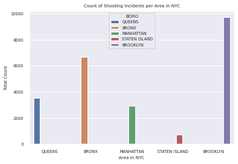

```python
import matplotlib.pyplot as plt
import seaborn as sns
# Here is the data visualization of what we currently have with all years accumulated.
data['BORO'].value_counts()
fig, ax = plt.subplots()
ax = sns.countplot(x=data.BORO, hue=data.BORO, data=data)
ax.set(xlabel="Area in NYC",ylabel="Total Count",title="Count of Shooting Incidents per Area in NYC")
plt.show()
# Let's try to find a way to measure individually throughout the years!
```

```
Frequency of incidents in 2019: 158
```

|  | OCCUR_DATE | BORO | STATISTICAL_MURDER_FLAG | PERP_AGE_GROUP | PERP_SEX | PERP_RACE | VIC_AGE_GROUP | VIC_SEX | VIC_RACE | X_COORD_CD | Y_COORD_CD | Latitude | Longitude | YR | frequency |
| --- | --- | --- | --- | --- | --- | --- | --- | --- | --- | --- | --- | --- | --- | --- | --- |
| 0 | 08/23/2019 | QUEENS | False | NaN | NaN | NaN | 25-44 | M | BLACK | 1037451 | 193561 | 40.697805 | -73.808141 | 2019 | 158 |
| 969 | 04/11/2016 | QUEENS | False | NaN | NaN | NaN | 25-44 | M | BLACK | 1033861 | 192835 | 40.695833 | -73.821093 | 2016 | 190 |
| 970 | 07/21/2010 | QUEENS | False | NaN | NaN | NaN | 18-24 | M | BLACK | 1056075 | 198425 | 40.711024 | -73.740925 | 2010 | 288 |
| 984 | 07/01/2015 | QUEENS | False | NaN | NaN | NaN | 25-44 | M | BLACK | 1049487 | 191469 | 40.691983 | -73.764755 | 2015 | 205 |
| 987 | 01/11/2008 | QUEENS | False | NaN | NaN | NaN | 18-24 | M | BLACK | 1046405 | 187113 | 40.680049 | -73.775909 | 2008 | 326 |
| 1010 | 05/12/2014 | QUEENS | False | NaN | NaN | NaN | 18-24 | M | BLACK | 1049751 | 183237 | 40.669386 | -73.763883 | 2014 | 218 |
| 1025 | 06/05/2011 | QUEENS | False | NaN | NaN | NaN | 18-24 | M | BLACK HISPANIC | 1025575 | 209708 | 40.742188 | -73.850870 | 2011 | 264 |
| 1030 | 07/21/2018 | QUEENS | False | 25-44 | M | BLACK | 25-44 | M | BLACK | 1,003,963 | 214,344 | 40.754988 | -73.928849 | 2018 | 146 |
| 1031 | 07/08/2009 | QUEENS | False | 18-24 | M | BLACK | 25-44 | M | BLACK | 1045402 | 188750 | 40.684549 | -73.779511 | 2009 | 278 |
| 1038 | 07/06/2006 | QUEENS | False | 25-44 | M | BLACK | 25-44 | M | BLACK | 1048450 | 181281 | 40.664027 | -73.768592 | 2006 | 296 |
| 1097 | 05/03/2013 | QUEENS | True | 18-24 | M | BLACK | 18-24 | M | BLACK | 1043920 | 156137 | 40.595044 | -73.785142 | 2013 | 185 |
| 1197 | 09/23/2012 | QUEENS | False | 18-24 | M | BLACK | 18-24 | M | BLACK | 1052235 | 192115 | 40.693735 | -73.754839 | 2012 | 290 |
| 1250 | 08/14/2007 | QUEENS | False | 18-24 | M | BLACK | 25-44 | M | BLACK | 1035139 | 152935 | 40.586309 | -73.816785 | 2007 | 238 |
| 1263 | 07/19/2017 | QUEENS | False | <18 | M | BLACK HISPANIC | 18-24 | M | BLACK HISPANIC | 1020090 | 210317 | 40.743884 | -73.870661 | 2017 | 143 |
| 21626 | 06/19/2020 | QUEENS | False | NaN | NaN | NaN | 25-44 | M | BLACK | 1016807 | 179007 | 40.657958 | -73.882660 | 2020 | 302 |

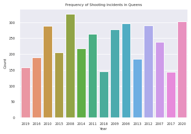

```python
data['YR'] = data.apply (lambda row: (row["OCCUR_DATE"].split("/"))[2], axis=1)
brooklyn_data = data
bronx_data = data
manhattan_data = data
statenisland_data = data

areas = data[~(data['BORO'] == 'QUEENS')].index
new = data
new = new.drop(areas)
count = 0
# Here is one way to count frequencies of a year...
# But this only counts one year, and we still need to update values in the dataframe
for index, row in new.iterrows():
    if row["YR"] == '2019':
        count+=1
print("Frequency of incidents in 2019: " + str(count)) # Printing our count for 2019

fig, ax = plt.subplots()
# But using pythonic functions makes this very easy!
new['frequency'] = new['YR'].map(new['YR'].value_counts()).fillna(0).astype(int)
new_df = new.drop_duplicates(subset="YR", keep='first', inplace=False)
new_df.sort_values(by='YR')
sns.barplot(x=new_df.YR, y=new_df.frequency, data=new_df)
ax.set(xlabel="Year",ylabel="Count",title="Frequency of Shooting Incidents in Queens")
sns.set(font_scale = 0.7)
new_df
```

```python
manhattan_data
```

|  | OCCUR_DATE | BORO | STATISTICAL_MURDER_FLAG | PERP_AGE_GROUP | PERP_SEX | PERP_RACE | VIC_AGE_GROUP | VIC_SEX | VIC_RACE | X_COORD_CD | Y_COORD_CD | Latitude | Longitude | YR |
| --- | --- | --- | --- | --- | --- | --- | --- | --- | --- | --- | --- | --- | --- | --- |
| 0 | 08/23/2019 | QUEENS | False | NaN | NaN | NaN | 25-44 | M | BLACK | 1037451 | 193561 | 40.697805 | -73.808141 | 2019 |
| 1 | 11/27/2019 | BRONX | False | <18 | M | BLACK | 25-44 | F | BLACK | 1006789 | 237559 | 40.818700 | -73.918571 | 2019 |
| 2 | 02/02/2019 | MANHATTAN | False | 18-24 | M | WHITE HISPANIC | 18-24 | M | BLACK HISPANIC | 999347 | 227795 | 40.791916 | -73.945480 | 2019 |
| 3 | 10/24/2019 | STATEN ISLAND | True | 25-44 | M | BLACK | 25-44 | F | BLACK | 938149 | 171781 | 40.638064 | -74.166108 | 2019 |
| 4 | 08/22/2019 | BRONX | False | 25-44 | M | BLACK HISPANIC | 18-24 | M | BLACK | 1008224 | 250621 | 40.854547 | -73.913339 | 2019 |
| ... | ... | ... | ... | ... | ... | ... | ... | ... | ... | ... | ... | ... | ... | ... |
| 23563 | 08/21/2020 | BRONX | True | NaN | NaN | NaN | 45-64 | M | BLACK HISPANIC | 1007277 | 187698 | 40.681843 | -73.916978 | 2020 |
| 23564 | 07/03/2020 | QUEENS | False | <18 | M | BLACK | <18 | M | BLACK | 1005993 | 241333 | 40.829060 | -73.921434 | 2020 |
| 23565 | 11/21/2020 | BROOKLYN | True | NaN | NaN | NaN | 45-64 | M | WHITE | 1046405 | 187113 | 40.680049 | -73.775909 | 2020 |
| 23566 | 01/18/2020 | BRONX | False | NaN | NaN | NaN | 45-64 | M | BLACK | 1011373 | 182202 | 40.666746 | -73.902232 | 2020 |
| 23567 | 11/21/2020 | BROOKLYN | False | 25-44 | M | BLACK | 25-44 | M | BLACK | 999475 | 172871 | 40.641163 | -73.945142 | 2020 |

23568 rows × 14 columns

[figure not shown]

```python
# Brooklyn
areas = brooklyn_data[~(brooklyn_data['BORO'] == 'BROOKLYN')].index
new = brooklyn_data
new.drop(areas, inplace=True)
fig, ax = plt.subplots()
new['frequency'] = new['YR'].map(new['YR'].value_counts()).fillna(0).astype(int)
new_df = new.drop_duplicates(subset="YR", keep='first', inplace=False)
new_df.sort_values(by='YR')
sns.barplot(x=new_df.YR, y=new_df.frequency, data=new_df)
ax.set(xlabel="Year",ylabel="Count",title="Frequency of Shooting Incidents in Manhattan")
sns.set(font_scale = 0.7)
```

[figure not shown]

```python
# Manhattan
areas = manhattan_data[~(manhattan_data['BORO'] == 'MANHATTAN')].index
new = manhattan_data
new.drop(areas)

fig, ax = plt.subplots()
new['frequency'] = new['YR'].map(new['YR'].value_counts()).fillna(0).astype(int)
new_df = new.drop_duplicates(subset="YR", keep='first', inplace=False)
new_df.sort_values(by='YR')
sns.barplot(x=new_df.YR, y=new_df.frequency, data=new_df)
ax.set(xlabel="Year",ylabel="Count",title="Frequency of Shooting Incidents in Manhattan")
sns.set(font_scale = 0.7)
```

[figure not shown]

```python
# Staten Island
areas = statenisland_data[~(statenisland_data['BORO'] == 'STATEN ISLAND')].index
new = statenisland_data
new.drop(areas)

fig, ax = plt.subplots()
new['frequency'] = new['YR'].map(new['YR'].value_counts()).fillna(0).astype(int)
new_df = new.drop_duplicates(subset="YR", keep='first', inplace=False)
new_df.sort_values(by='YR')
sns.barplot(x=new_df.YR, y=new_df.frequency, data=new_df)
ax.set(xlabel="Year",ylabel="Count",title="Frequency of Shooting Incidents in Staten Island")
sns.set(font_scale = 0.7)
```

Let's observe some other properties about the data and see what we find. We can use our earlier saved dataframe to check these properties out.

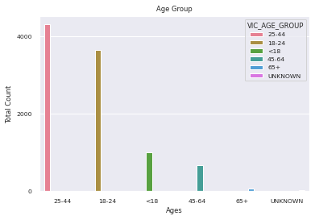

```python
# What about age?
saved_data['VIC_AGE_GROUP'].value_counts()
fig, ax = plt.subplots()
ax = sns.countplot(x=saved_data.VIC_AGE_GROUP, hue=saved_data.VIC_AGE_GROUP, data=saved_data, palette="husl")
ax.set(xlabel="Ages",ylabel="Total Count",title="Age Group")
sns.set(font_scale = 2)
plt.show()
```

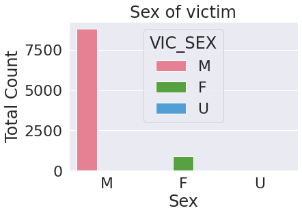

```python
# What about sex?
saved_data['VIC_SEX'].value_counts()
fig, ax = plt.subplots()
ax = sns.countplot(x=saved_data.VIC_SEX, hue=saved_data.VIC_SEX, data=saved_data, palette="husl")
ax.set(xlabel="Sex",ylabel="Total Count",title="Sex of victim")
sns.set(font_scale = 2)
plt.show()
```

[figure not shown]

```python
# What about race?
saved_data['VIC_RACE'].value_counts()
fig, ax = plt.subplots()
ax = sns.countplot(x=saved_data.VIC_RACE, hue=saved_data.VIC_RACE, data=saved_data, palette="husl")
ax.set(xlabel="Race",ylabel="Total Count",title="Race of victim")
sns.set_theme(font_scale = 0.39)
plt.show()
```

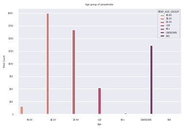

```python
# What about age?
saved_data['PERP_AGE_GROUP'].value_counts()
fig, ax = plt.subplots()
ax = sns.countplot(x=saved_data.PERP_AGE_GROUP, hue=saved_data.PERP_AGE_GROUP, data=saved_data, palette="flare")
ax.set(xlabel="Age",ylabel="Total Count",title="Age group of perpetrator")
sns.set_theme(font_scale = 0.5)
plt.show()
```

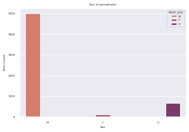

```python
# What about sex?
saved_data['PERP_SEX'].value_counts()
fig, ax = plt.subplots()
ax = sns.countplot(x=saved_data.PERP_SEX, hue=saved_data.PERP_SEX, data=saved_data, palette="flare")
ax.set(xlabel="Sex",ylabel="Total Count",title="Sex of perpetrator")
plt.show()
```

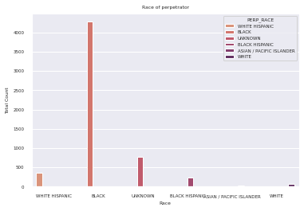

```python
# What about race?
saved_data['PERP_RACE'].value_counts()
fig, ax = plt.subplots()
ax = sns.countplot(x=saved_data.PERP_RACE, hue=saved_data.PERP_RACE, data=saved_data, palette="flare")
ax.set(xlabel="Race",ylabel="Total Count",title="Race of perpetrator")
sns.set(font_scale = 0.6)
plt.show()
```

An important aspect of any data science is contextualizing the data that is being worked with.

Violence, in general is frequently cyclic in nature, being passed from previous abuse - we also have to acknowledge the disparities in communities that have been present through the years.

#### Hypothesis testing and machine learning

Analysis/Hypothesis testing and ML is essentially saying, we have this idea on how these two components of the data are related - now how are we gonna test it?

We will see what this would like for this specific dataset but first let's understand a bit more of what these terms mean.

- Hypothesis testing is testing a given hypothesis by comparing it with the null hypothesis. What exactly is a null hypothesis? The null hypothesis is a default hypothesis in which the relationship and statistical significance between two items is measured to be zero.
- A null hypothesis here would be that factors like location, age, race, sex, gender, and so on do not play a role in being a victim.

My hypothesis is that they do, due to the history of gender bias/inequality, history of racial minority communities being underfunded by the government, age being a factor in accessibility to weaponry. The graphs shown so far demonstrate this to an extent as well. For location, I am hypothesizing that the high numbers of incidents of some areas are simply a result of more people in the area due to the variation in the graphs shown in the visualization overtime.

Let's begin with a null hypothesis that gender and being a victim have no correlation and see what we can find out.

```python
ml_data = saved_data # grabbing the previously saved data
from sklearn import linear_model
standard_features = ml_data[['VIC_SEX', 'PERP_SEX']]
for ind, row in ml_data.iterrows():
    if row["VIC_SEX"] == "M":
        ml_data["VGENDER"][ind] = 1
    else:
        ml_data["VGENDER"][ind] = 0
    if row["PERP_SEX"] == "M":
        ml_data["PGENDER"][ind] = 1
    else:
        ml_data["PGENDER"][ind] = 0
```

[output not shown]

```python
standard_features = ml_data[['VGENDER', 'PGENDER']] # our standard features
lr1 = linear_model.LinearRegression()
lr1.fit(standard_features.drop('PGENDER', axis=1), standard_features['VGENDER'])
# printing beta zero
print(lr1.intercept_)
# printing beta one
print(lr1.coef_)
standard_features["Prediction"] = lr1.predict(standard_features.drop('PGENDER', axis=1))
standard_features["Residual"] = standard_features["PGENDER"] - standard_features["Prediction"]
```

[output not shown]

#### Communication of insights attained

It can not go without saying that this step in the data science pipeline is the most critical component. If all the other steps are correctly executed, and what the data shows isn't properly explained then it is useless. In order to be able to correctly execute this step, we need to be communicating what we have done and why. There isn’t a point in doing data science if it doesn’t result in changes or knowledge being learned from it.

What does this mean and why does it matter?

```python
# This is just for style purposes, it can be ignored :-)
%%capture
!pip install jupyterthemes
```

```python
%%capture
!jt -t monokai
```